# Predicting Credit Risk

German dataset

L.RANT

10 janvier, 2020

# 1 Introduction

L’objet de ce document est de montrer comment mettre en oeuvre les méthodes présentées dans la section pré-traitement. Nous appliquerons ces méthodes sur les données German Credit à l’aide du logiciel Rstudio.

Après avoir importé les données à l’aide du logiciel, nous donnerons un aperçu général du jeu données puis développerons la partie exploratoire. A la suite de cette exploration, nous envisagerons différentes façons de prétraiter les données puis nous ferons une prédiction pour accorder ou non un credit avec differents algorithmes.

# 2 Importation des données

```r
setwd("C:/Users/lnzb7292/Downloads/STA211")
don<-read.table("C:/Users/lnzb7292/Downloads/STA211/german.data",sep=" ")
#don<-read.table("C:/Users/lnzb7292/Downloads/STA211/credit-german.txt",sep='\t', header=TRUE)

str(don)
```

```
## 'data.frame':    1000 obs. of  21 variables:
##  $ V1 : Factor w/ 4 levels "A11","A12","A13",..: 1 2 4 1 1 4 4 2 4 2 ...
##  $ V2 : int  6 48 12 42 24 36 24 36 12 30 ...
##  $ V3 : Factor w/ 5 levels "A30","A31","A32",..: 5 3 5 3 4 3 3 3 3 5 ...
##  $ V4 : Factor w/ 10 levels "A40","A41","A410",..: 5 5 8 4 1 8 4 2 5 1 ...
##  $ V5 : int  1169 5951 2096 7882 4870 9055 2835 6948 3059 5234 ...
##  $ V6 : Factor w/ 5 levels "A61","A62","A63",..: 5 1 1 1 1 5 3 1 4 1 ...
##  $ V7 : Factor w/ 5 levels "A71","A72","A73",..: 5 3 4 4 3 3 5 3 4 1 ...
##  $ V8 : int  4 2 2 2 3 2 3 2 2 4 ...
##  $ V9 : Factor w/ 4 levels "A91","A92","A93",..: 3 2 3 3 3 3 3 3 1 4 ...
##  $ V10: Factor w/ 3 levels "A101","A102",..: 1 1 1 3 1 1 1 1 1 1 ...
##  $ V11: int  4 2 3 4 4 4 4 2 4 2 ...
##  $ V12: Factor w/ 4 levels "A121","A122",..: 1 1 1 2 4 4 2 3 1 3 ...
##  $ V13: int  67 22 49 45 53 35 53 35 61 28 ...
##  $ V14: Factor w/ 3 levels "A141","A142",..: 3 3 3 3 3 3 3 3 3 3 ...
##  $ V15: Factor w/ 3 levels "A151","A152",..: 2 2 2 3 3 3 2 1 2 2 ...
##  $ V16: int  2 1 1 1 2 1 1 1 1 2 ...
##  $ V17: Factor w/ 4 levels "A171","A172",..: 3 3 2 3 3 2 3 4 2 4 ...
##  $ V18: int  1 1 2 2 2 2 1 1 1 1 ...
##  $ V19: Factor w/ 2 levels "A191","A192": 2 1 1 1 1 2 1 2 1 1 ...
##  $ V20: Factor w/ 2 levels "A201","A202": 1 1 1 1 1 1 1 1 1 1 ...
##  $ V21: int  1 2 1 1 2 1 1 1 1 2 ...
```

La commande str permet d’avoir un rapide aperçu des données importées.

On constate que les noms des variables, comme ceux de leurs modalités (pour les variables qualitatives) ne sont pas du tout explicites. A partir du descriptif des données (disponible ici), on renomme les différentes variables et les modalités.

```r
# Modification des noms des variables
colnames(don)<-c(
  "Status",
  "Duration",
  "History",
  "Purpose",
  "Credit.Amount",
  "Savings account/bonds",
  "Length.of.current.employment",
  "Instalment.per.cent",
  "Sex.Marital.Status",
  "Guarantors",
  "Duration.in.Current.address",
  "Property",
  "Age.years",
  "Other.installment.plans",
  "Housing",
  "No.of.Credits.at.this.Bank",
  "Job",
  "No.of.dependents"
  ,"Telephone",
 "Foreign.Worker",
 "Creditability")

# Modification des noms des modalit?s des variables qualitatives
levels(don$Status)<-c("lt.0","0.to.200","gt.200","none")

levels(don$History)<-c("noCredit.allPaid","thisBank.AllPaid","paidDuly","delay","critical")

levels(don$Purpose)<-c("NewCar", "UsedCar", "Other","Furniture.Equipment", "Radio.Television",
"DomesticAppliance", "Repairs", "Education", "Retraining",
"Business")

levels(don$`Savings account/bonds`)<-c("lt.100", "100.to.500", "500.to.1000", "gt.1000", "Unknown"
)

levels(don$Length.of.current.employment)<-c("lt.1", "1.to.4", "4.to.7", "gt.7", "Unemployed")

levels(don$Sex.Marital.Status)<-c("Male.Divorced.Seperated", "Female.NotSingle", "Male.Single",
"Male.Married.Widowed")

levels(don$Guarantors)<-c("None", "CoApplicant", "Guarantor")

levels(don$Property)<-c("RealEstate", "Insurance", "CarOther", "Unknown")

levels(don$Other.installment.plans)<-c("Bank", "Stores", "None")

levels(don$Housing)<-c("Rent", "Own", "ForFree")

levels(don$Job)<-c("UnemployedUnskilled", "UnskilledResident", "SkilledEmployee",
"Management.SelfEmp.HighlyQualified")

levels(don$Foreign.Worker)<-c("yes","no")

levels(don$Telephone)<-c("none","yes")
```

On modifie également le type de certaines variables

```r
#Codage des variables quantitatives en type "numeric" (plutot que "integer")
don$Duration<-as.numeric(don$Duration)
don$Credit.Amount<-as.numeric(don$Credit.Amount)
don$Age.years<-as.numeric(don$Age.years)

#Codage de la variable r?ponse en type "factor"
don$Creditability<-as.factor(don[,"Creditability"])
levels(don$Creditability)<-c("good","bad")
```

# 3 Aperçu général

```r
#nombre d'individus et variables
dim(don)
```

```
## [1] 1000   21
```

```r
#nature des variables
table(sapply(don,class))
```

```
##
##  factor integer numeric
##      14       4       3
```

```r
#variables qualitatives
var.factor<-which(sapply(don,class)=="factor")
names(var.factor)
```

```
##  [1] "Status"                       "History"
##  [3] "Purpose"                      "Savings account/bonds"
##  [5] "Length.of.current.employment" "Sex.Marital.Status"
##  [7] "Guarantors"                   "Property"
##  [9] "Other.installment.plans"      "Housing"
## [11] "Job"                          "Telephone"
## [13] "Foreign.Worker"               "Creditability"
```

```r
#variables quantitatives
var.numeric<-which(sapply(don,class)=="numeric"|sapply(don,class)=="integer")
names(var.numeric)
```

```
## [1] "Duration"                    "Credit.Amount"
## [3] "Instalment.per.cent"         "Duration.in.Current.address"
## [5] "Age.years"                   "No.of.Credits.at.this.Bank"
## [7] "No.of.dependents"
```

# 4 Exploration

## 4.1 Analyse univariée

### 4.1.1 Variables quantitatives

#### 4.1.1.1 Indicateurs statistiques

```r
# chargement de la librarie
library(stargazer)
# affichage de quelques indicateurs statistiques pour variables quantitatives
stargazer(don,summary.stat=c("n","min","p25","median","mean","p75","max","sd"),type = "text")
```

```
##
## ==========================================================================================
## Statistic                     N   Min Pctl(25) Median    Mean    Pctl(75)  Max   St. Dev.
## ------------------------------------------------------------------------------------------
## Duration                    1,000  4     12      18     20.903      24      72    12.059
## Credit.Amount               1,000 250 1,365.5  2,319.5 3,271.258 3,972.2  18,424 2,822.737
## Instalment.per.cent         1,000  1     2        3      2.973      4       4      1.119
## Duration.in.Current.address 1,000  1     2        3      2.845      4       4      1.104
## Age.years                   1,000 19     27      33     35.546      42      75    11.375
## No.of.Credits.at.this.Bank  1,000  1     1        1      1.407      2       4      0.578
## No.of.dependents            1,000  1     1        1      1.155      1       2      0.362
## ------------------------------------------------------------------------------------------
```

On peut remarquer qu’aucune des variables n’est constante. De telles variables n’auraient en effet aucun intérêt pour l’analyse.

# 4.1.1.2 Représentations graphiques

On commence par visualiser les distributions marginales des variables via des diagrammes en barres et des histogrammes. Les variables Duration, Credit.Amount et Age.years ayant un grand nombre de valeurs distinctes, on les représentera via des histogrammes.

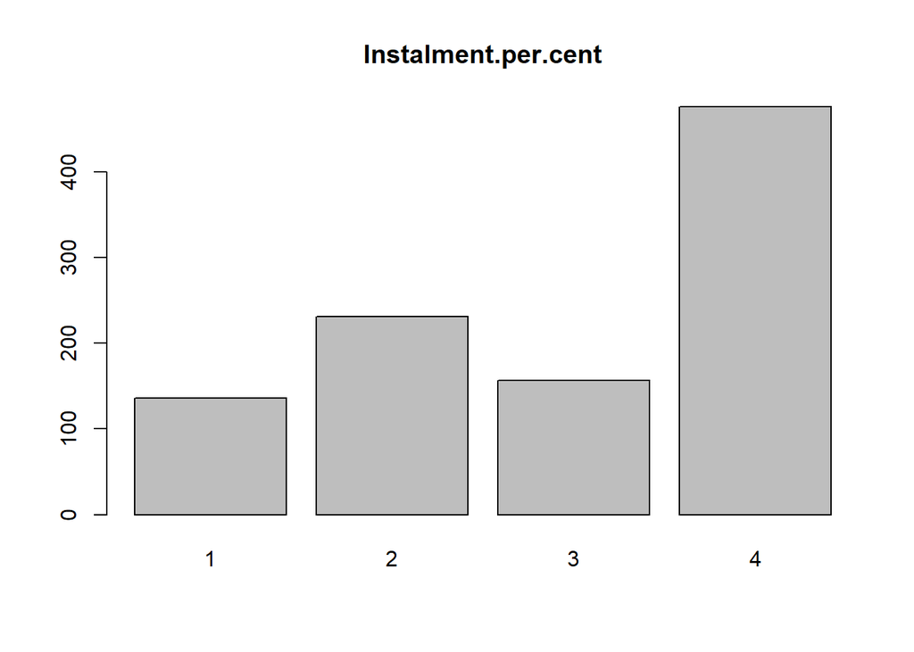

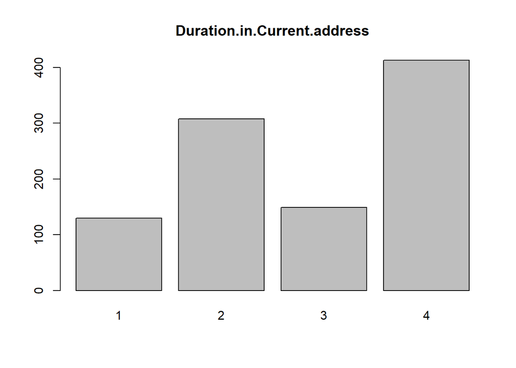

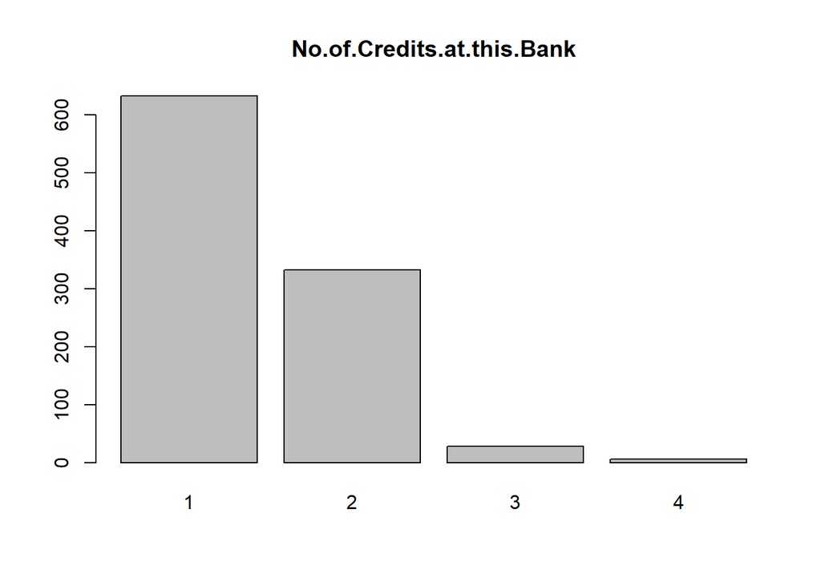

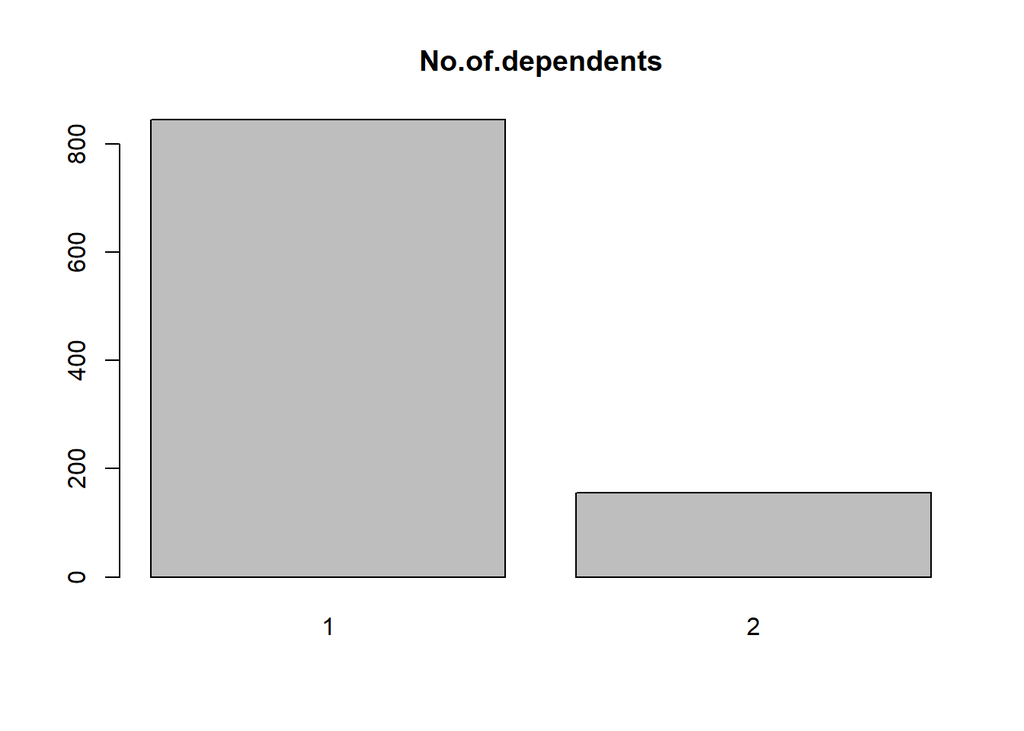

```
## $Instalment.per.cent
##      [,1]
## [1,]  0.7
## [2,]  1.9
## [3,]  3.1
## [4,]  4.3
##
## $Duration.in.Current.address
##      [,1]
## [1,]  0.7
## [2,]  1.9
## [3,]  3.1
## [4,]  4.3
##
## $No.of.Credits.at.this.Bank
##      [,1]
## [1,]  0.7
## [2,]  1.9
## [3,]  3.1
## [4,]  4.3
##
## $No.of.dependents
##      [,1]
## [1,]  0.7
## [2,]  1.9
```

```r
#diagrammes en barres
varbarplot<-c("Instalment.per.cent", "Duration.in.Current.address", "No.of.Credits.at.this.Bank", "No.of.dependents")
mapply(don[,varbarplot],
       FUN=function(xx,name){barplot(table(xx),main=name)},
       name=varbarplot)
```

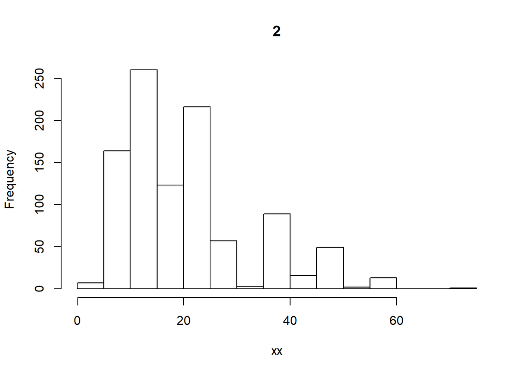

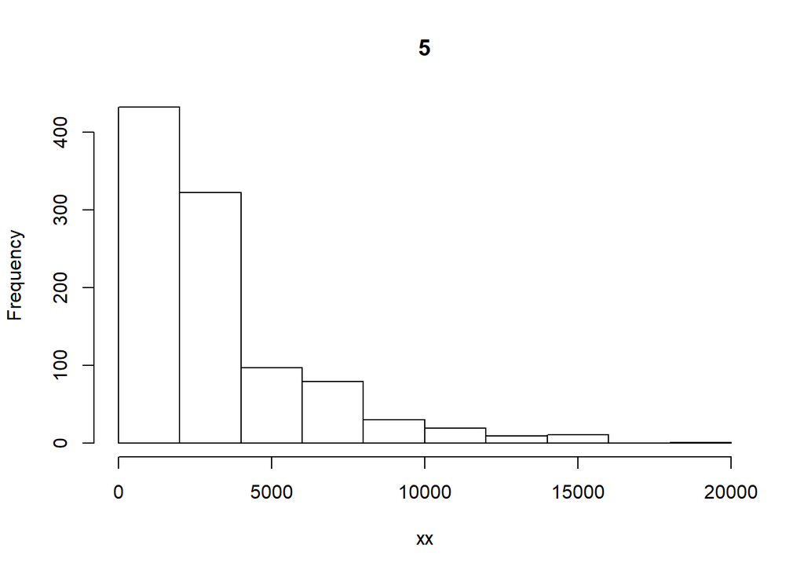

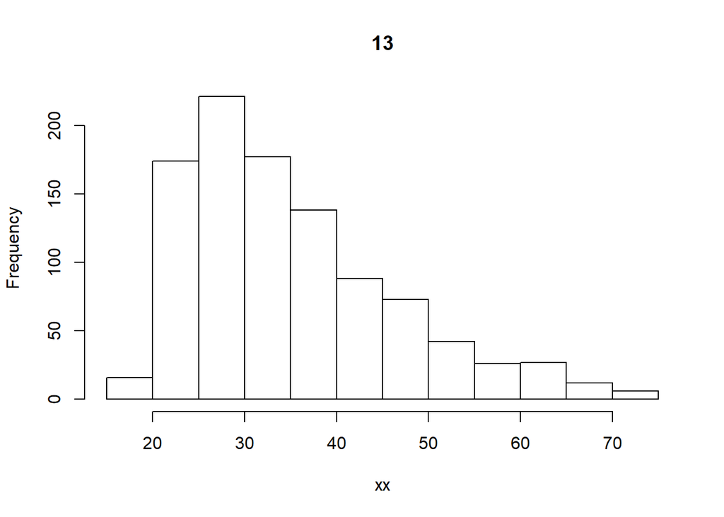

```
##          Duration   Credit.Amount Age.years
## breaks   Numeric,16 Numeric,11    Integer,13
## counts   Integer,15 Integer,10    Integer,12
## density  Numeric,15 Numeric,10    Numeric,12
## mids     Numeric,15 Numeric,10    Numeric,12
## xname    "xx"       "xx"          "xx"
## equidist TRUE       TRUE          TRUE
```

```r
#histogrammes
varhist<-var.numeric[!names(var.numeric)%in%varbarplot]
mapply(don[,varhist],
       FUN=function(xx,name){hist(xx,main=name)},
       name=varhist)
```

```r
library(car)
```

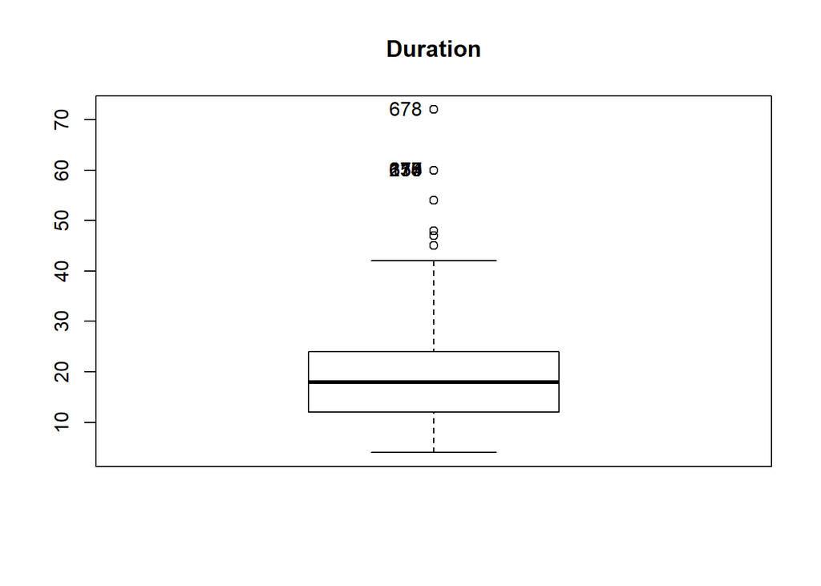

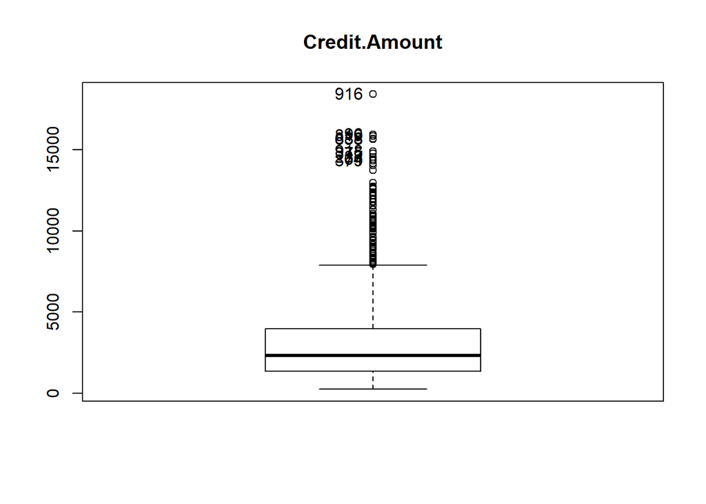

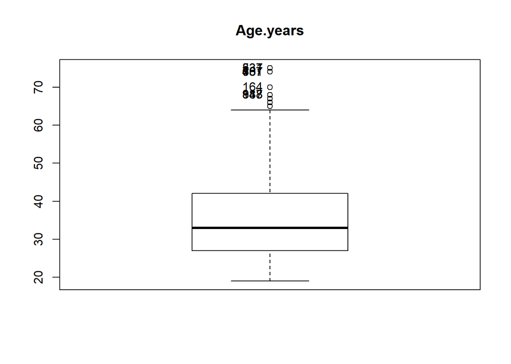

[output not shown]

```r
mapply(don[,varhist],
       FUN=function(xx,name){Boxplot(xx,main=name,id.n=2,ylab="")},
       name=names(varhist))
```

Bien que différentes valeurs semblent relativement élevées, il est difficile de prendre dès à présent la décision de gérer ces valeurs (par exemple en les considérant comme manquantes et en les imputant). Ce choix pourra être fait a posteriori si nécessaire.

### 4.1.2 Variables qualitatives

On repère des modalités rares via les diagrammes en barres (on pourrait de façon équivalente visualiser cette information sous forme de tableaux)

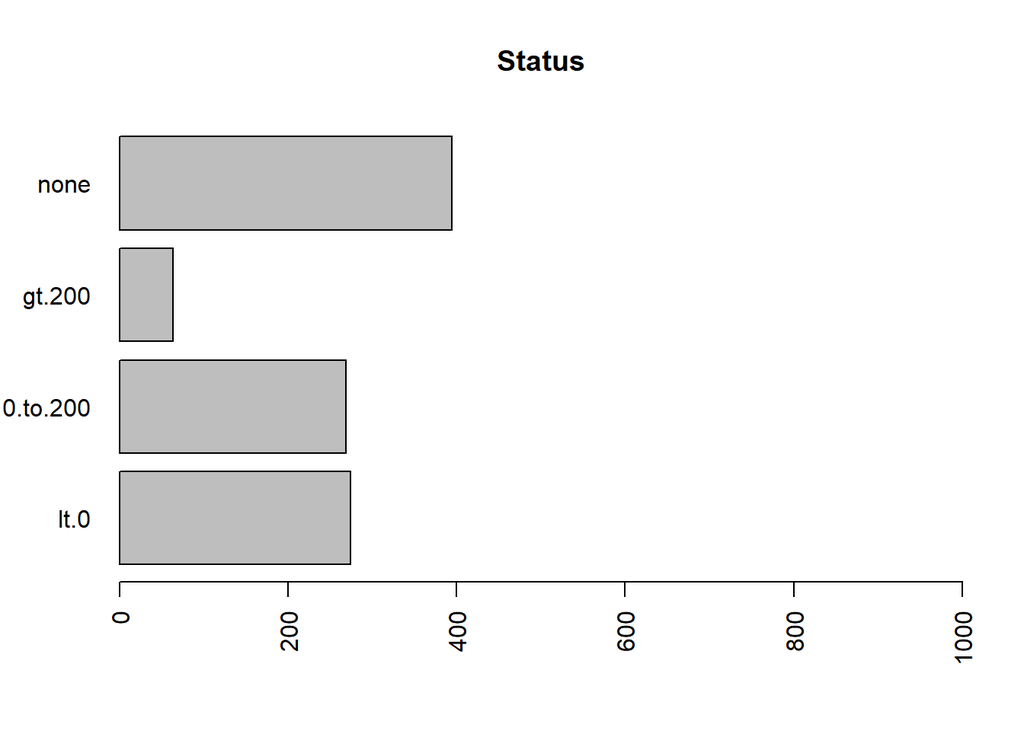

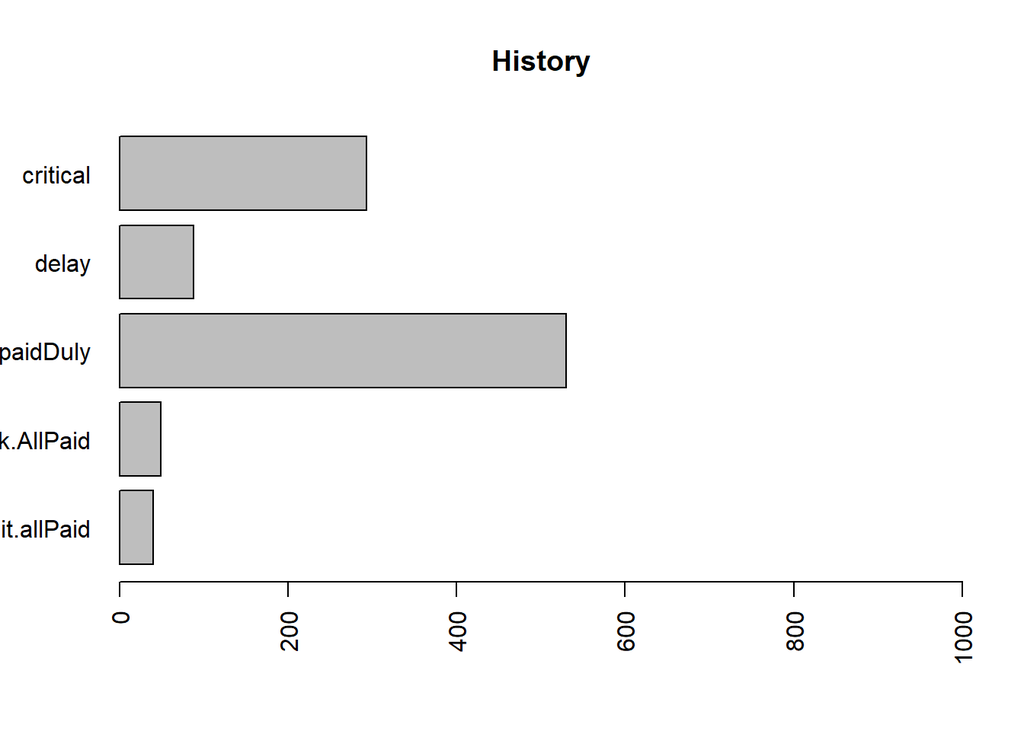

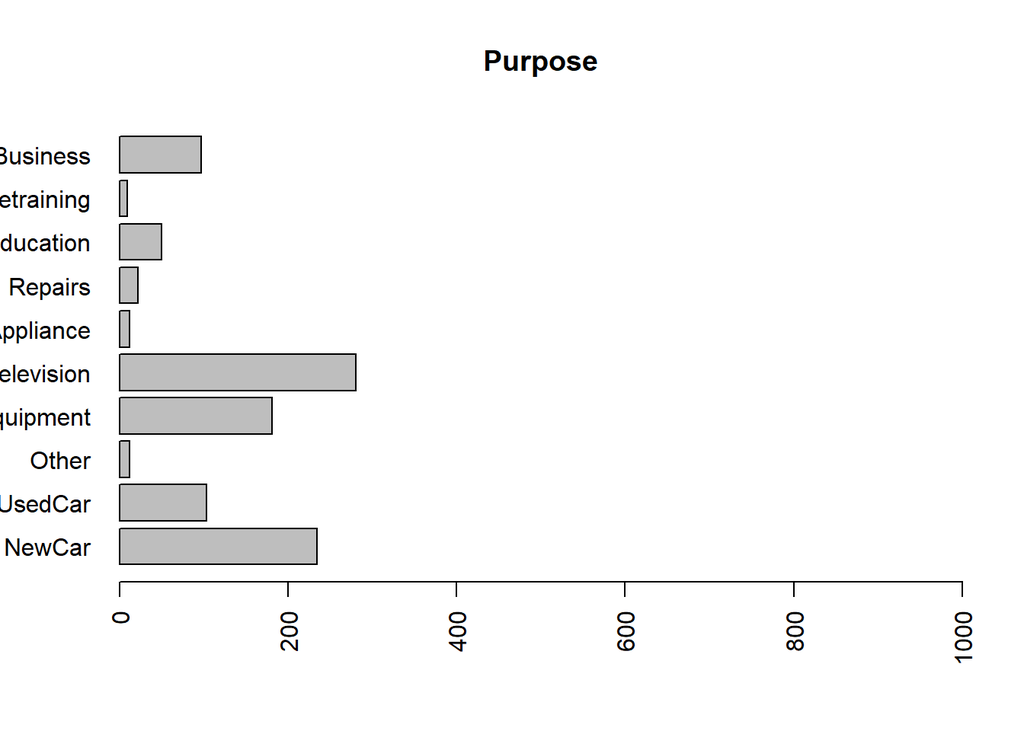

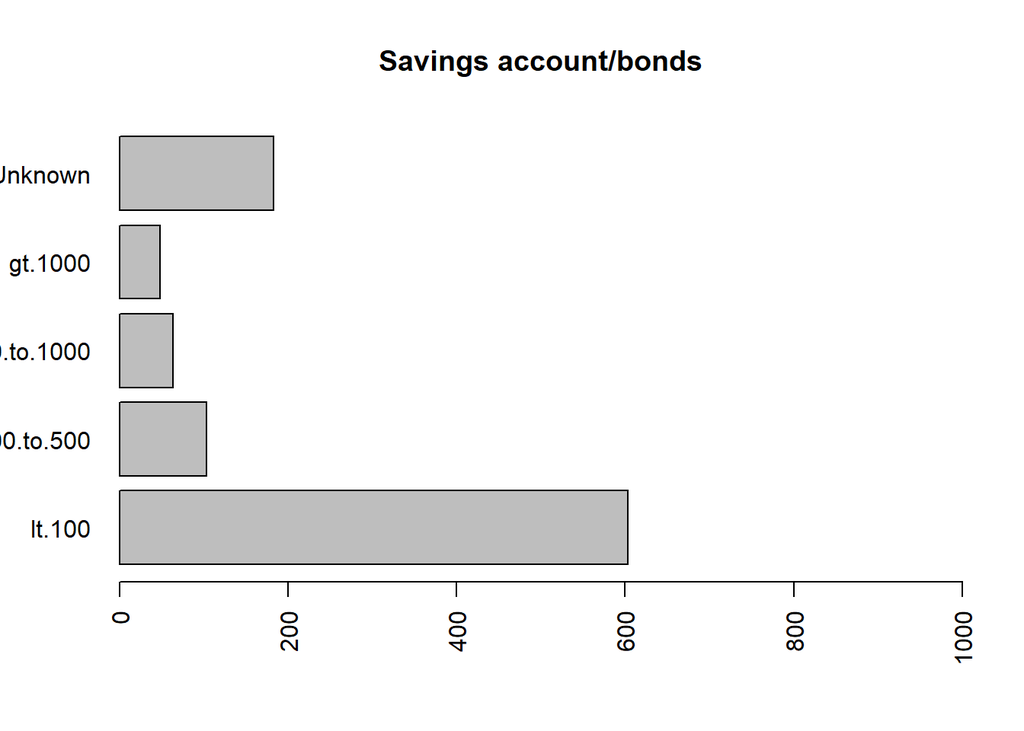

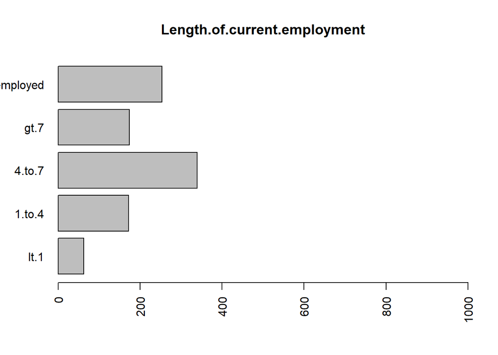

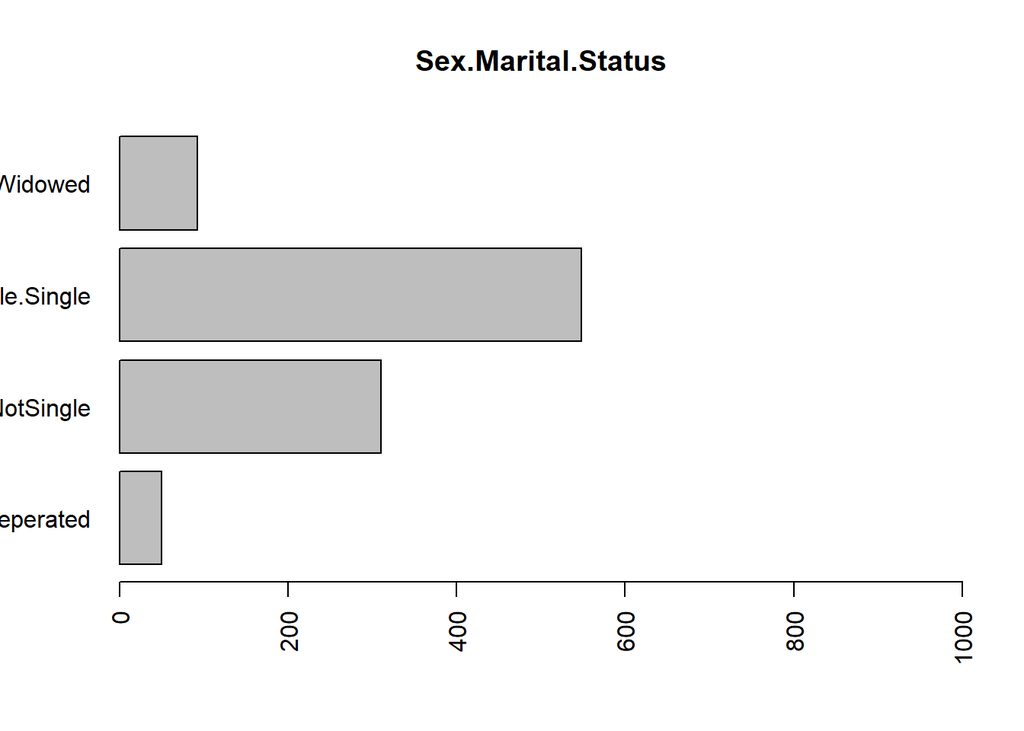

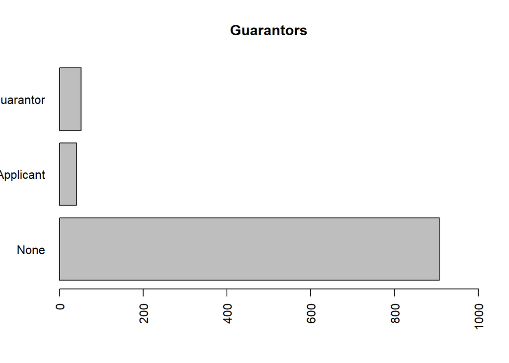

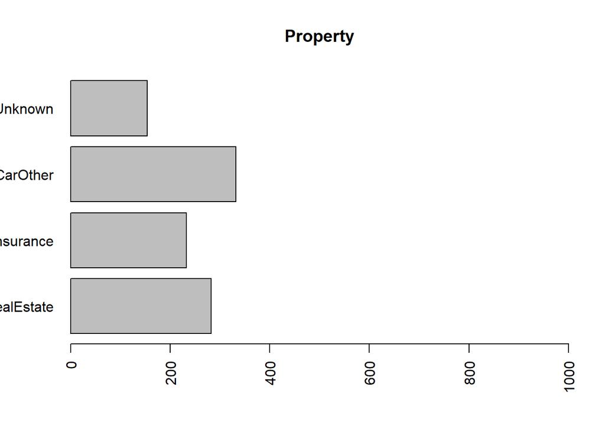

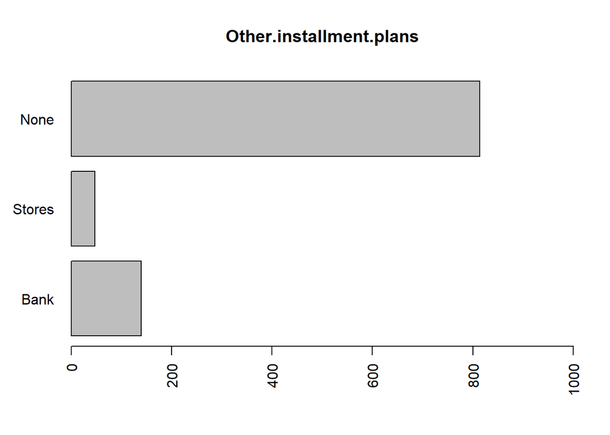

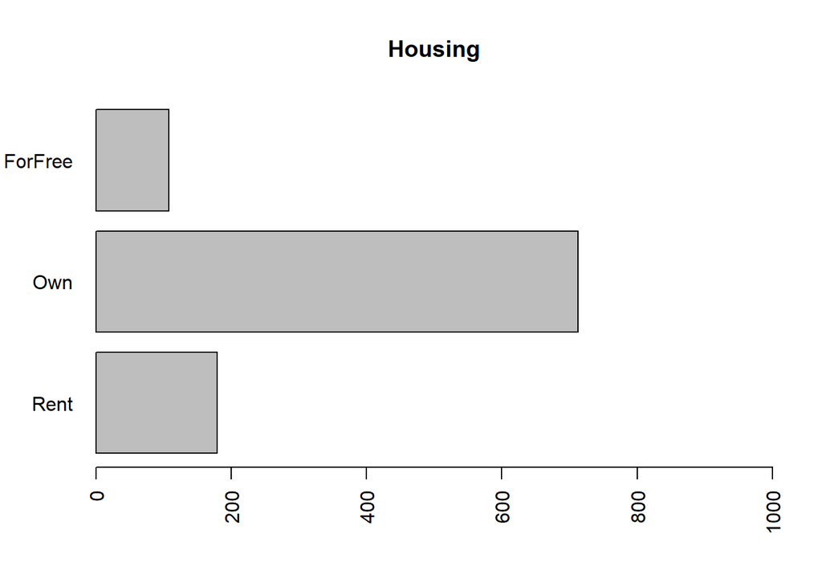

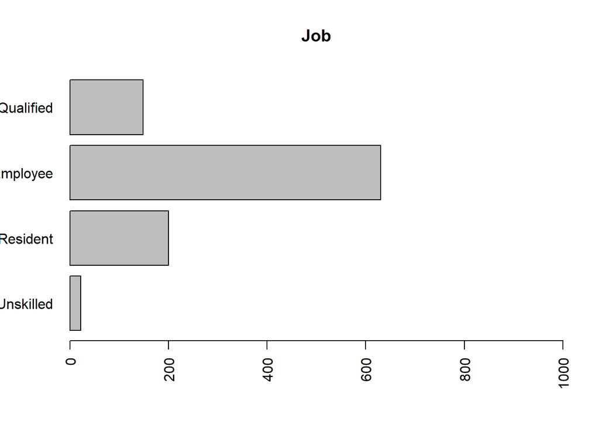

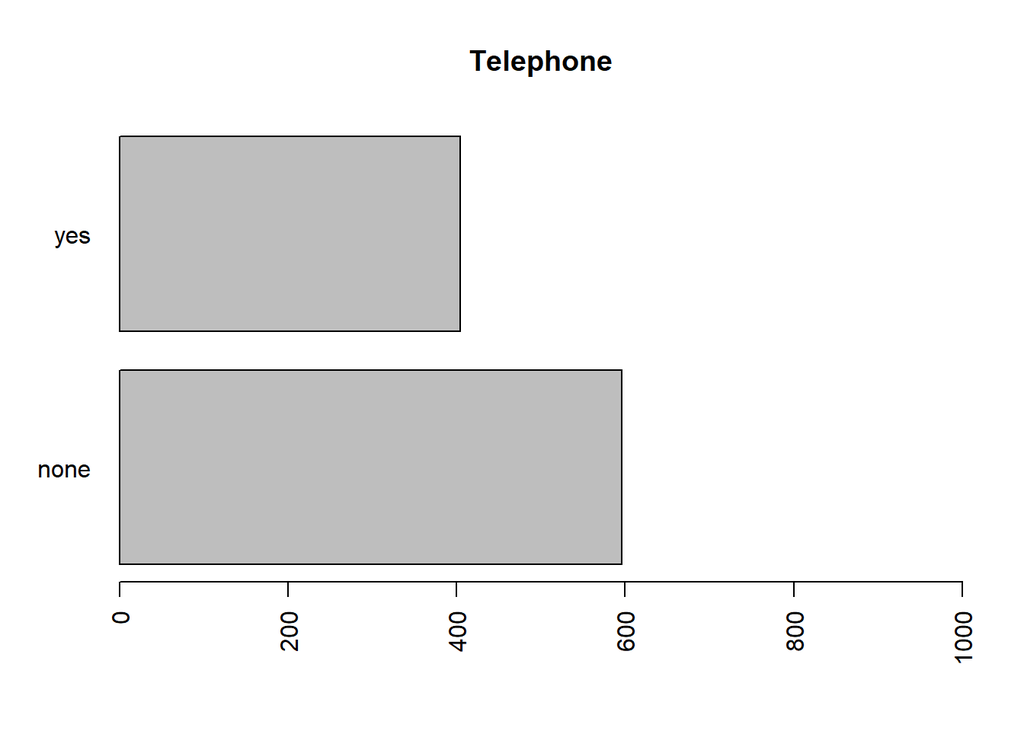

[2 more figures not shown]

```
## $Status
##      [,1]
## [1,]  0.7
## [2,]  1.9
## [3,]  3.1
## [4,]  4.3
##
## $History
##      [,1]
## [1,]  0.7
## [2,]  1.9
## [3,]  3.1
## [4,]  4.3
## [5,]  5.5
##
## $Purpose
##       [,1]
##  [1,]  0.7
##  [2,]  1.9
##  [3,]  3.1
##  [4,]  4.3
##  [5,]  5.5
##  [6,]  6.7
##  [7,]  7.9
##  [8,]  9.1
##  [9,] 10.3
## [10,] 11.5
##
## $`Savings account/bonds`
##      [,1]
## [1,]  0.7
## [2,]  1.9
## [3,]  3.1
## [4,]  4.3
## [5,]  5.5
##
## $Length.of.current.employment
##      [,1]
## [1,]  0.7
## [2,]  1.9
```

[output cut: 42 more lines]

```
##
## $Telephone
##      [,1]
## [1,]  0.7
## [2,]  1.9
##
## $Foreign.Worker
##      [,1]
## [1,]  0.7
## [2,]  1.9
##
## $Creditability
##      [,1]
## [1,]  0.7
## [2,]  1.9
```

```r
mapply(don[,var.factor],
       FUN=function(xx,name){barplot(table(xx),main=name,horiz = TRUE,las=2,xlim=c(0,1000))},
       name=names(var.factor))
```

En fonction de la distribution de la variable réponse au sein de chaque modalité définie par ces variables, il pourra pertinent ou non d’effectuer certains regroupements. On aura besoin pour cela d’effectuer une analyse bivariée.

## 4.2 Analyse bivariée

Etant dans un cas de classification supervisée, nous distinguons l’analyse bivariée des couples mettant en jeu la variable réponse, de celle des couples ne portant que sur des variables explicatives.

### 4.2.1 Lien entre variables explicatives et variable réponse

####4.2.1.1 Linéarité

Afin d’identifier la nature du lien entre les variables quantitatives et la réponse, on représente la proportion de bons payeurs en fonction des variables quantitatives. Ce type d’analyse dans le cas d’une variable explicative continue nécessitera d’effectuer une discrétisation.

On commence par identifier le lien entre la variable Creditability et la variable Duration.

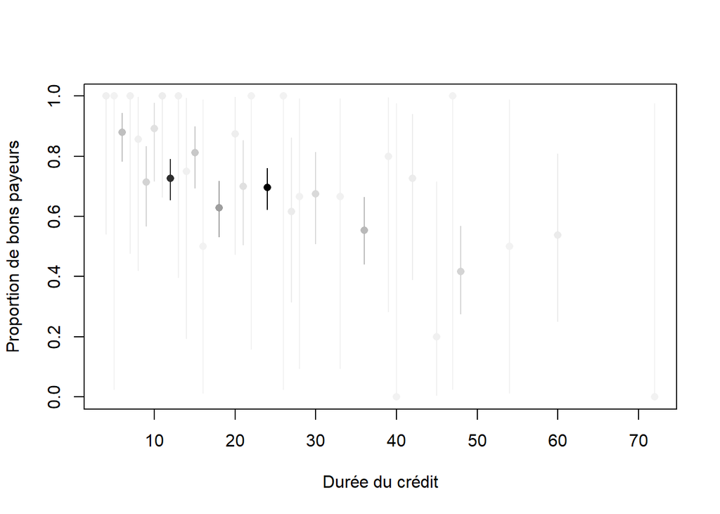

```r
#calcul de la proportion de bons payeurs pour chaque valeur de la durée de credit
cont.table<-table(don$Duration,don$Creditability)
prof.lignes<-prop.table(cont.table,1)




#calcul des bornes de l'intervalle de confiance associee
res.binom.test<-mapply(cont.table[,1],
                       FUN=binom.test,
                       n=rowSums(cont.table),
                       SIMPLIFY = FALSE)
ci<-sapply(res.binom.test,"[[","conf.int")

# repr?sentation des proportions en fonction de la dur?e de credit
# (coloration en fonction du nombre d'obervations pour la dur?e consid?ree)
abscisses<-as.numeric(rownames(prof.lignes))
col<-gray.colors(184,.95,0)[rowSums(cont.table)]

# affichage des proportions
plot(abscisses,
     prof.lignes[,1],
     pch=16,
     col=col,
     xlab="Durée du crédit",
     ylab="Proportion de bons payeurs")

# affichage des intervalles de confiance
for(ii in 1:length(abscisses)){
  segments(x0=abscisses[ii],
           y0=ci[1,ii],
           x1=abscisses[ii],
           y1=ci[2,ii],
           col=col[ii])
}
```

Sur ce graphique, un point est d’autant plus noir que le nombre d’individus utilisés pour déterminer la proportion correspondante est grande. Les points les plus noirs sont donc ceux avec les intervalles de confiance les plus courts.

On voit que la proportion de bons payeurs décroît de façon relativement linéaire avec la durée du Crédit. On recommence pour la variable Age en effectuant au préalable une discrétisation en 20 classes.

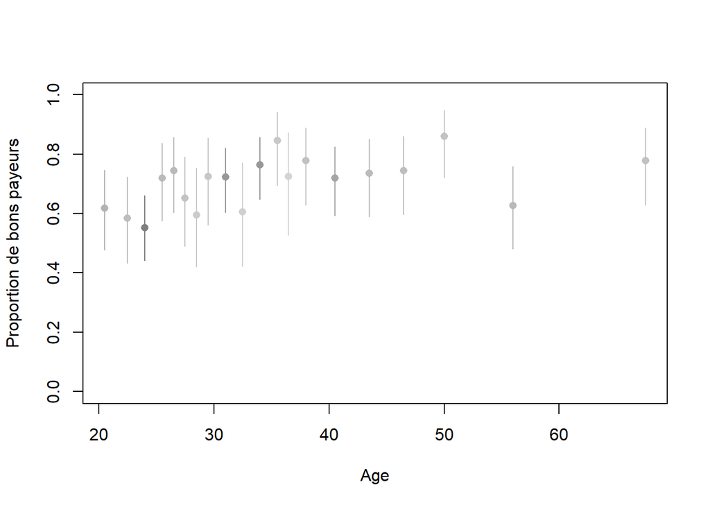

```r
ordrequantiles<-seq(0,1,1/20)
Age.years.new<-cut(don$Age.years,breaks = quantile(don$Age.years,probs = ordrequantiles))


cont.table<-table(Age.years.new,don$Creditability)
prof.lignes<-prop.table(cont.table,1)
res.binom.test<-mapply(cont.table[,1],
                       FUN=binom.test,
                       n=rowSums(cont.table),
                       SIMPLIFY = FALSE)
ci<-sapply(res.binom.test,"[[","conf.int")
abscisses<-hist(don$Age.years,quantile(don$Age.years,probs =ordrequantiles),plot = FALSE)$mids
col<-gray.colors(112,.95,0)[rowSums(cont.table)]


plot(abscisses,
     prof.lignes[,1],
     pch=16,
     col=col,
     xlab="Age",
     ylab="Proportion de bons payeurs",
     ylim=c(0,1))

for(ii in 1:length(abscisses)){
  segments(x0=abscisses[ii],
           y0=ci[1,ii],
           x1=abscisses[ii],
           y1=ci[2,ii],
           col=col[ii])
}
```

On voit que la liaison est plutôt non-monotone. On pourra découper la variable Age en 3 classes pour gérer cette non-linéarité.

On visualise enfin le lien avec les autres variables quantitatives (discrètes avec peu de modalités)

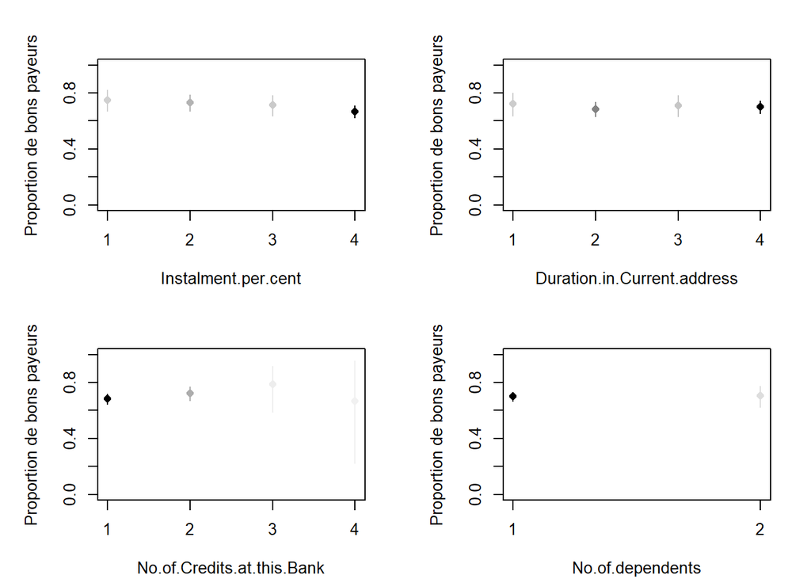

```r
par(mfrow=c(2,2),mar=c(4,5, 3, 2) + 0.1)

for(ii in c("Instalment.per.cent", "Duration.in.Current.address", "No.of.Credits.at.this.Bank", "No.of.dependents")){
  xx<-don[,ii]
  cont.table<-table(cbind.data.frame(xx,don$Creditability))
  prof.lignes<-prop.table(cont.table,1)
  res.binom.test<-mapply(cont.table[,1],
                         FUN=binom.test,
                         n=rowSums(cont.table),
                         SIMPLIFY = FALSE)
  ci<-sapply(res.binom.test,"[[","conf.int")

  #graphique pour la variable courante
  abscisses<-as.numeric(rownames(prof.lignes))
  col<-gray.colors(max(rowSums(cont.table)),.95,0)[rowSums(cont.table)]
  plot(x = abscisses,
       y=prof.lignes[,1],
       pch=16,
       col=col,
       ylab="Proportion de bons payeurs",
       xlab=ii,
       xaxt="n",
       ylim=c(0,1))
  axis(side=1,at = abscisses,labels = abscisses,xlab=varbarplot[ii])
  for(ii in 1:length(abscisses)){
    segments(x0=abscisses[ii],
             y0=ci[1,ii],
             x1=abscisses[ii],
             y1=ci[2,ii],
             col=col[ii])
  }
}
```

#### 4.2.1.2 Identification des variables les plus discriminantes

On regarde ensuite quelles sont les variables les plus liées au statut bon/mauvais payeur.

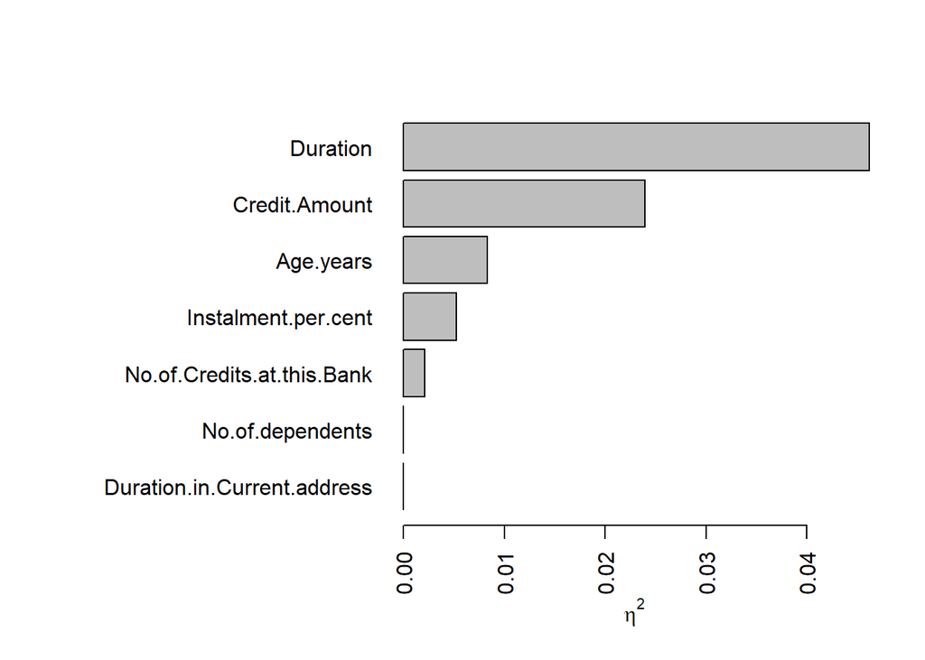

```r
library(BioStatR)

#calcul des rapport de corr?lation
res.eta2<-sapply(don[,var.numeric],eta2,y=don$Creditability)

#tri par valeurs d?croissantes
res.eta2<-sort(res.eta2)

#repr?sentation
par(mar=c(5, 15, 4, 2) + 0.1)#pour g?rer les marges du graphique
barplot(res.eta2,horiz = TRUE,las=2,xlab=expression(eta^2))
```

Parmi les variables quantitatives, les liaisons les plus fortes sont observées pour les variables Duration et Credit Amount. Au contraire, les variables No.of.dependents et Duration in Current address n’apparaissent pas comme discriminantes.

```r
#Creation d'une matrice contenant les variables qualitatives et quantitatives discr?tes (sans la variable Creditability)
don.cramer<-don[,c(var.factor)]
don.cramer<-don.cramer[,-which(colnames(don.cramer)=="Creditability")]

#calcul du V de cramer entre Creditability et les autres variables non continues de don.cramer
library(DescTools)
```

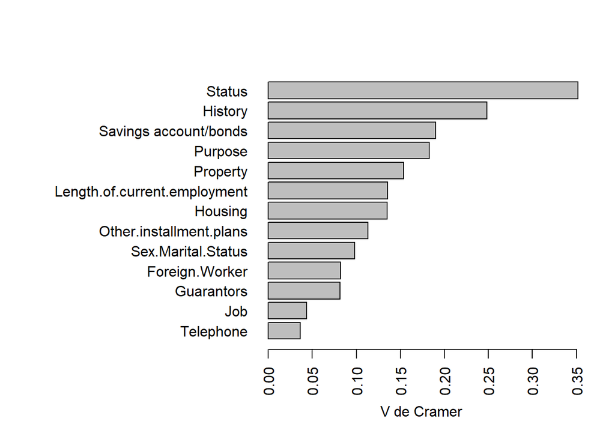

```r
res.cramer<-sapply(don.cramer,
                   FUN=function(xx,yy){CramerV(table(xx,yy))},
                   yy=don$Creditability)

#tri par valeurs d?croissantes
res.cramer<-sort(res.cramer)

#repr?sentation
par(mar=c(5, 15, 4, 2) + 0.1)
barplot(res.cramer,horiz = TRUE,las=2,xlab="V de Cramer")
```

Parmi les variables qualitatives, les variables les plus liées sont Status et History, tandis que les variables Job et Telephone ne semblent pas discriminantes.

Ces analyses pourront être utiles en vue d’une réduction du nombre de colonnes, les variables les moins discriminantes seront a priori amenées à être écarter en priorité. Attention toutefois car on a évalué ici un lien direct entre les variables explicatives et la réponse, il est possible que la liaison soit plus complexe, mettant en jeu des liaisons de type interaction par exemple. Pour les détecter, on pourrait utiliser une régression logistique ou des arbres binaires (cf Tufféry (2007)).

On pourra tester le caractère significatif des liaisons entre la variable réponse qualitative en utilisant la fonction catdes du package FactoMineR permettant de décrire une partition (ici selon les modalités good et bad de la variable réponse) à partir des variables quantitatives, et des modalités des variables qualitatives (voir Lebart, Morineau, and Piron (2006) pour la méthode et le site du package pour la lecture des sorties de la fonction). Notons néanmoins que ceci n’est pertinent que si le nombre d’observations est modéré, sans quoi toutes les variables risqueraient d’être considérées comme statistiquement reliées à la variable réponse. Par ailleurs, pour éviter les hypothèses paramètriques, il pourra être préférable d’utiliser des intervalles de confiance bootstrap (Lejeune (2010)).

```r
library(FactoMineR)
catdes(don,num.var = ncol(don))
```

```
##
## Link between the cluster variable and the categorical variables (chi-square test)
## =================================================================================
##                                   p.value df
## Status                       1.218902e-26  3
## History                      1.279187e-12  4
## Savings.account/bonds        2.761214e-07  4
## Property                     2.858442e-05  3
## Housing                      1.116747e-04  2
## Purpose                      1.157491e-04  9
## Length.of.current.employment 1.045452e-03  4
## Other.installment.plans      1.629318e-03  2
## Foreign.Worker               9.443096e-03  1
## Sex.Marital.Status           2.223801e-02  3
## Guarantors                   3.605595e-02  2
##
## Description of each cluster by the categories
## =============================================
## $good
##                                      Cla/Mod   Mod/Cla Global      p.value
## Status=none                         88.32487 49.714286   39.4 2.358909e-26
## History=critical                    82.93515 34.714286   29.3 3.173751e-09
## Savings.account/bonds=Unknown       82.51366 21.571429   18.3 2.352366e-05
## Housing=Own                         73.91304 75.285714   71.3 2.817260e-05
## Property=RealEstate                 78.72340 31.714286   28.2 1.252793e-04
## Other.installment.plans=None        72.48157 84.285714   81.4 4.645612e-04
## Purpose=Radio.Television            77.85714 31.142857   28.0 6.063689e-04
## Purpose=UsedCar                     83.49515 12.285714   10.3 1.042084e-03
## Savings.account/bonds=gt.1000       87.50000  6.000000    4.8 4.320887e-03
## Foreign.Worker=no                   89.18919  4.714286    3.7 6.074413e-03
## Sex.Marital.Status=Male.Single      73.35766 57.428571   54.8 1.101034e-02
## Length.of.current.employment=gt.7   77.58621 19.285714   17.4 1.480775e-02
## Savings.account/bonds=500.to.1000   82.53968  7.428571    6.3 2.109007e-02
## Purpose=Education                   56.00000  4.000000    5.0 3.260917e-02
## Sex.Marital.Status=Female.NotSingle 64.83871 28.714286   31.0 1.799662e-02
## Housing=ForFree                     59.25926  9.142857   10.8 1.199396e-02
## Foreign.Worker=yes                  69.26272 95.285714   96.3 6.074413e-03
## Housing=Rent                        60.89385 15.571429   17.9 4.036907e-03
## Other.installment.plans=Bank        58.99281 11.714286   13.9 2.929790e-03
## Purpose=NewCar                      61.96581 20.714286   23.4 2.571853e-03
```

[output cut: 113 more lines]

```
## Instalment.per.cent    1.118155 2.211026e-02
## Credit.Amount       2821.325155 1.004177e-06
## Duration              12.052784 1.096893e-11
##
## $bad
##                        v.test Mean in category Overall mean sd in category
## Duration             6.793179        24.860000       20.903       13.26048
## Credit.Amount        4.890818      3938.126667     3271.258     3529.92100
## Instalment.per.cent  2.288468         3.096667        2.973        1.08658
## Age.years           -2.880260        33.963333       35.546       11.20366
##                      Overall sd      p.value
## Duration              12.052784 1.096893e-11
## Credit.Amount       2821.325155 1.004177e-06
## Instalment.per.cent    1.118155 2.211026e-02
## Age.years             11.369779 3.973467e-03
```

#### 4.2.1.3 Allure des distributions conditionnelles

La distribution des variables continues conditionnellement à la variable réponse est parfois déterminante pour l’utilisation de certains modèles, notamment l’analyse linéaire discriminante. On analyse donc la nature de ces distributions.

```r
# Chargement de la librarie lattice permettant de faire des graphiques relativement avanc?s
library(lattice)
library(gridExtra)
library(grid)
library(ggplot2)

# distribution conditionnelle de Age.Years
plot1<-lattice::histogram(~Age.years|Creditability,data=don,type="density",col="lightblue",ylab="Densit?")
```

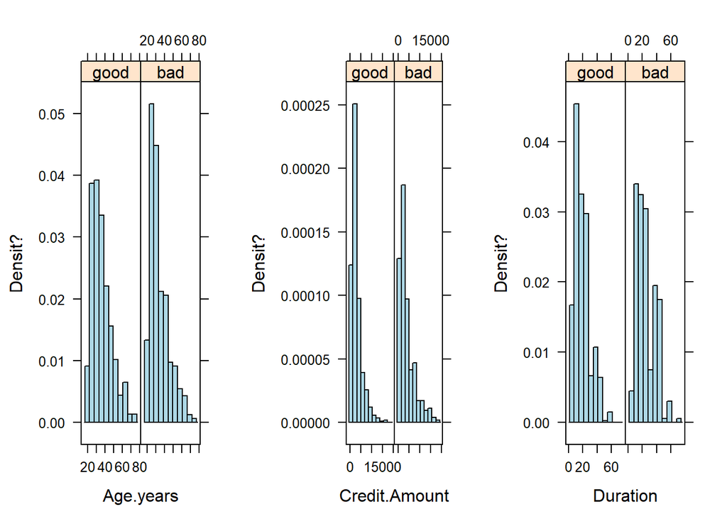

```r
# distribution conditionnelle de Credit.Amount
plot2<-lattice::histogram(~Credit.Amount|Creditability,data=don,type="density",col="lightblue",ylab="Densit?")
# distribution conditionnelle de Duration
plot3<-lattice::histogram(~Duration|Creditability,data=don,type="density",col="lightblue",ylab="Densit?")

# affichage
grid.arrange(plot1,plot2,plot3,nrow=1,ncol=3)
```

Clairement, les distributions conditionnelles des variables Age, Credit Amont et Duration ne sont pas normales. Peut-être sera-t-il nécessaire de transformer ces variables par la suite si cette normalité était requise par les méthodes employées. Notons qu’il est aussi possible de comparer certains indicateurs statistiques entre les deux groupes

```r
by(don[,-ncol(don)],
   INDICES = don$Creditability,
   FUN=stargazer,
   summary.stat=c("n","min","p25","median","mean","p75","max","sd"),
   type = "text")
```

```
##
## =======================================================================================
## Statistic                    N  Min Pctl(25) Median   Mean    Pctl(75)  Max   St. Dev.
## ---------------------------------------------------------------------------------------
## Duration                    700  4     12      18    19.207      24      60    11.080
## Credit.Amount               700 250 1,375.5  2,244  2,985.457 3,634.8  15,857 2,401.472
## Instalment.per.cent         700  1     2       3      2.920      4       4      1.128
## Duration.in.Current.address 700  1     2       3      2.843      4       4      1.108
## Age.years                   700 19     27      34    36.224     42.2     75    11.381
## No.of.Credits.at.this.Bank  700  1     1       1      1.424      2       4      0.585
## No.of.dependents            700  1     1       1      1.156      1       2      0.363
## ---------------------------------------------------------------------------------------
##
## ========================================================================================
## Statistic                    N  Min Pctl(25) Median    Mean    Pctl(75)  Max   St. Dev.
## ----------------------------------------------------------------------------------------
## Duration                    300  6     12      24     24.860      36      72    13.283
## Credit.Amount               300 433 1,352.5  2,574.5 3,938.127 5,141.5  18,424 3,535.819
## Instalment.per.cent         300  1     2        4      3.097      4       4      1.088
## Duration.in.Current.address 300  1     2        3      2.850      4       4      1.095
## Age.years                   300 19     25      31     33.963      40      74    11.222
## No.of.Credits.at.this.Bank  300  1     1        1      1.367      2       4      0.560
## No.of.dependents            300  1     1        1      1.153      1       2      0.361
## ----------------------------------------------------------------------------------------
```

```
## don$Creditability: good
##  [1] ""
##  [2] "======================================================================================="
##  [3] "Statistic                    N  Min Pctl(25) Median   Mean    Pctl(75)  Max   St. Dev. "
##  [4] "---------------------------------------------------------------------------------------"
##  [5] "Duration                    700  4     12      18    19.207      24      60    11.080  "
##  [6] "Credit.Amount               700 250 1,375.5  2,244  2,985.457 3,634.8  15,857 2,401.472"
##  [7] "Instalment.per.cent         700  1     2       3      2.920      4       4      1.128  "
##  [8] "Duration.in.Current.address 700  1     2       3      2.843      4       4      1.108  "
##  [9] "Age.years                   700 19     27      34    36.224     42.2     75    11.381  "
## [10] "No.of.Credits.at.this.Bank  700  1     1       1      1.424      2       4      0.585  "
## [11] "No.of.dependents            700  1     1       1      1.156      1       2      0.363  "
## [12] "---------------------------------------------------------------------------------------"
## --------------------------------------------------------
## don$Creditability: bad
##  [1] ""
##  [2] "========================================================================================"
##  [3] "Statistic                    N  Min Pctl(25) Median    Mean    Pctl(75)  Max   St. Dev. "
##  [4] "----------------------------------------------------------------------------------------"
##  [5] "Duration                    300  6     12      24     24.860      36      72    13.283  "
##  [6] "Credit.Amount               300 433 1,352.5  2,574.5 3,938.127 5,141.5  18,424 3,535.819"
##  [7] "Instalment.per.cent         300  1     2        4      3.097      4       4      1.088  "
##  [8] "Duration.in.Current.address 300  1     2        3      2.850      4       4      1.095  "
##  [9] "Age.years                   300 19     25      31     33.963      40      74    11.222  "
## [10] "No.of.Credits.at.this.Bank  300  1     1        1      1.367      2       4      0.560  "
## [11] "No.of.dependents            300  1     1        1      1.153      1       2      0.361  "
## [12] "----------------------------------------------------------------------------------------"
```

Pour les variables qualitatives, il sera intéressant d’identifier la distribution conditionnelle de la variable réponse en fonction des modalités des variables. Ceci permettra d’effectuer des regroupements de modalités préservant au mieux les liaisons entre ces variables et la variable réponse. On choisit donc de représenter la proportion de bons payeurs en fonction des modalités des différentes variables explicatives qualitatives.